# ExpHunterSuite: Differential Expression Report

## **Data quality control (QC)**

### **Correlation between samples:**

Here we show scatterplots comparing expression levels for all genes between the different samples, for i) all controls, ii) all treatment samples and iii) for all samples together.

These plots will only be produced when the total number of samples to compare within a group is less than or equal to 10.

#### **Correlation between control samples:**

Replicates within the same group tend to have Pearson correlation coefficients >= 0.96. Lower values may indicate problems with the samples.

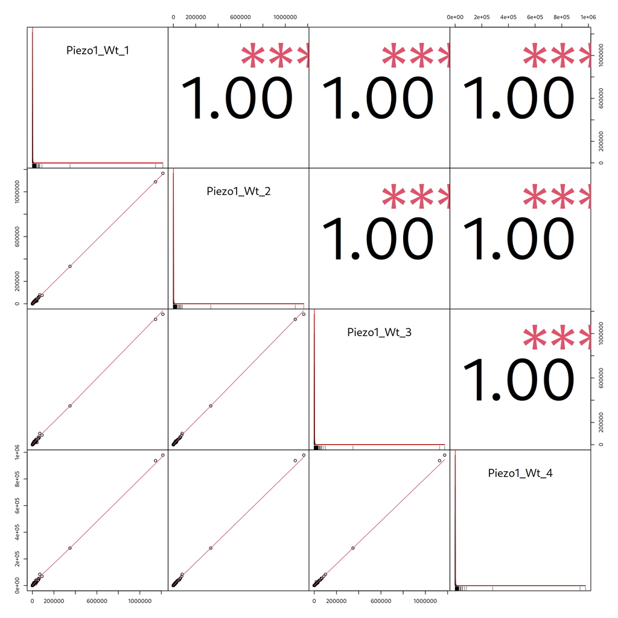

#### **Correlation between treatment samples:**

Replicates within the same group tend to have Pearson correlation coefficients >= 0.96. Lower values may indicate problems with the samples.

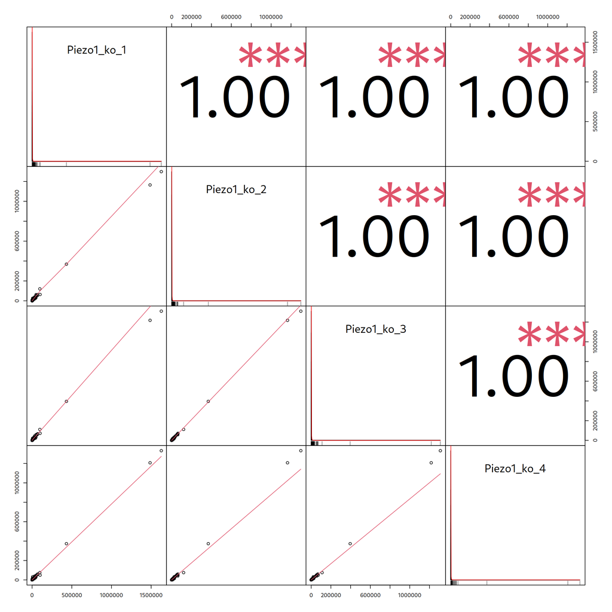

#### **Correlation between samples: All vs all replicates**

Correlation coefficients tend to be slightly higher between replicates from the same group than between replicates from different groups. If this is not the case, it may indicate mislabelling or other potential issues.

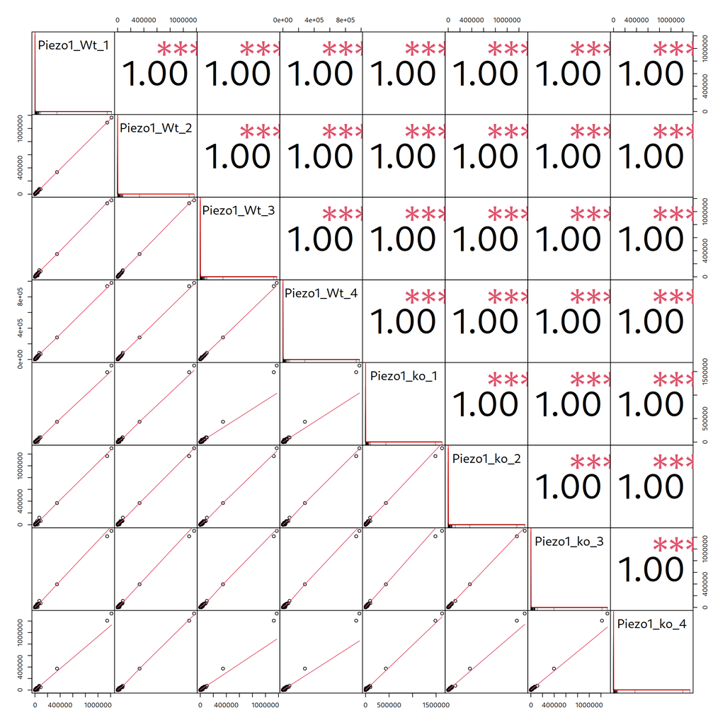

### **Heatmap and clustering showing correlation between replicates**

**BROWN: higher correlation; YELLOW: lower**

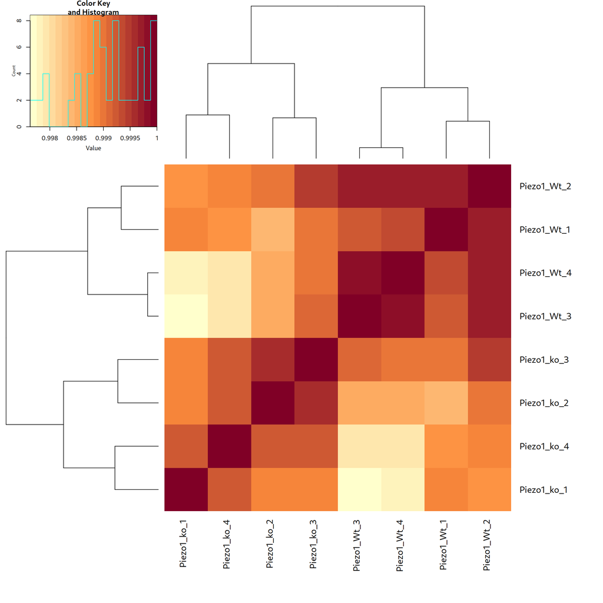

### **Principal Component Analysis**

This is a PCA plot of the count values normalized following the default method and then they are scaled:

#### **Inertia plot exploring variance explained by dimensions**

Graphical representation of PCA dimensions. The bars represent the percentage of total variance that summarize each dimension. The line measures the percentage of total variance accumulated in previous dimensions. The color distinguishes between significan or no significant dimensions. Only significant dimensions will be considered in the following plots.

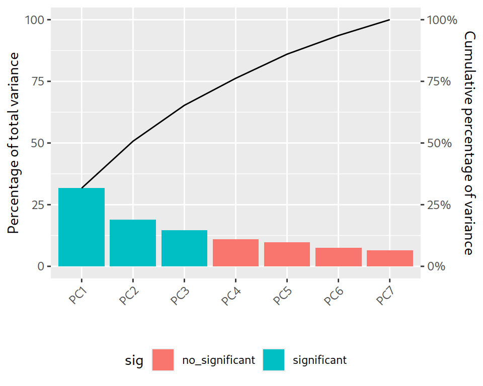

#### **Distribution of Eigenvectors**

The eigenvector contains the weights of each gene for the PC. Here are represented the distributions of the weights of each eigenvector. The vertical lines represent the quantiles.

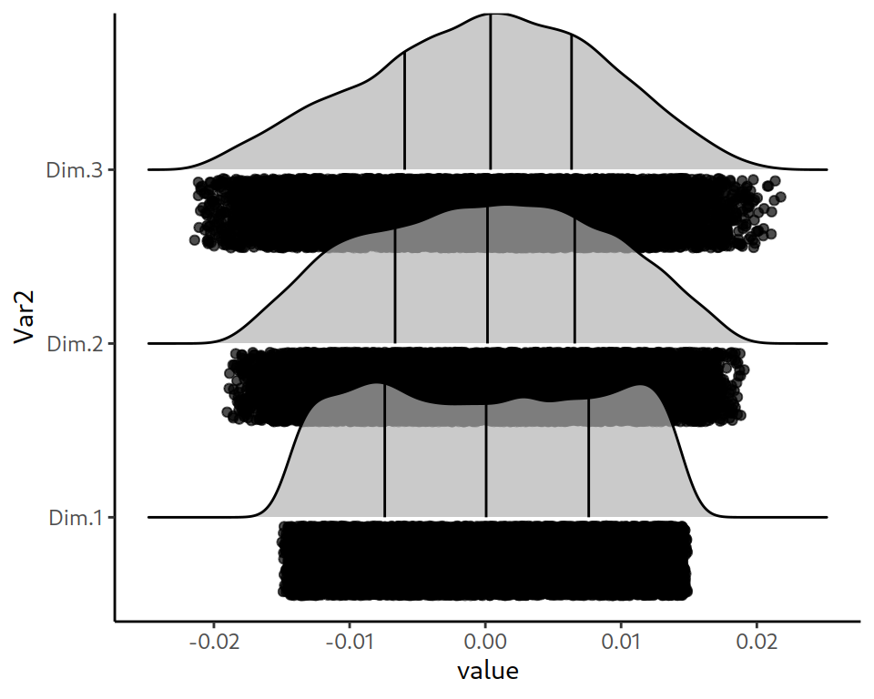

#### **Comparison of significant dimensions significant dimensions**

This plot compare the position of samples and their distribution in the significant dimensions. The color differenciate between the control (red) and treat (blue) samples.

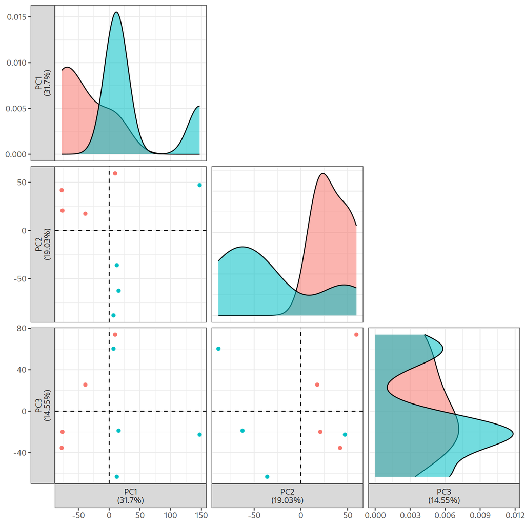

#### **Representation of the samples in the two first dimension of PCA**

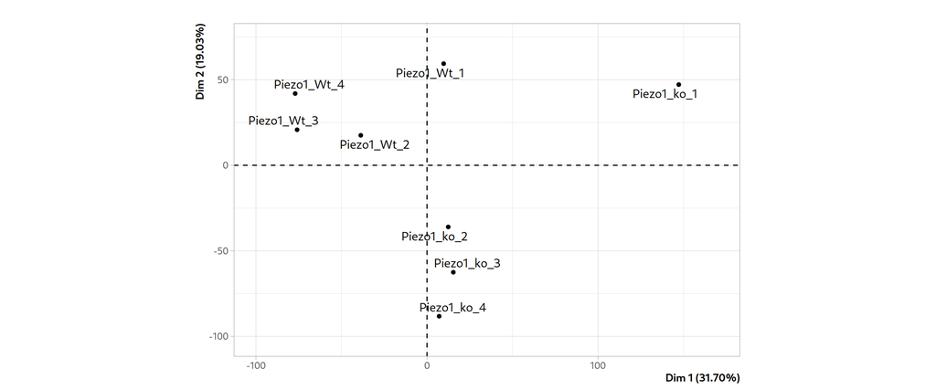

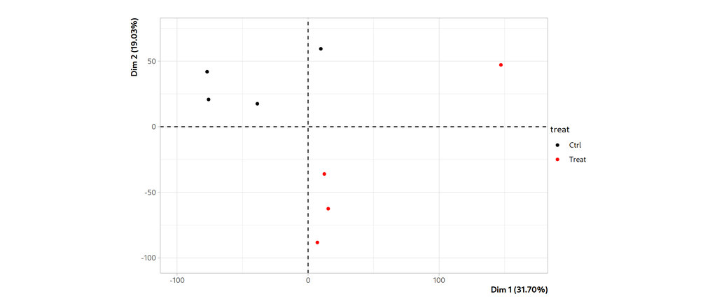

#### **Representation of the samples and the categories of qualitative valiables in the two first dimension of PCA**

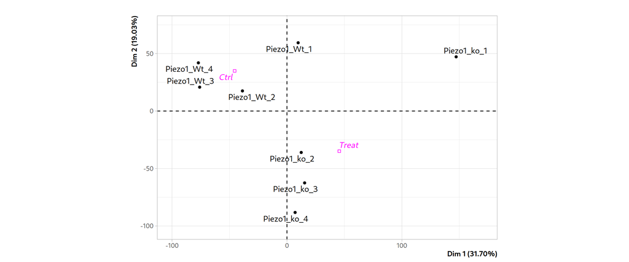

#### **Hierarchical clustering of individuals using first 3 significant PCA dimensions**

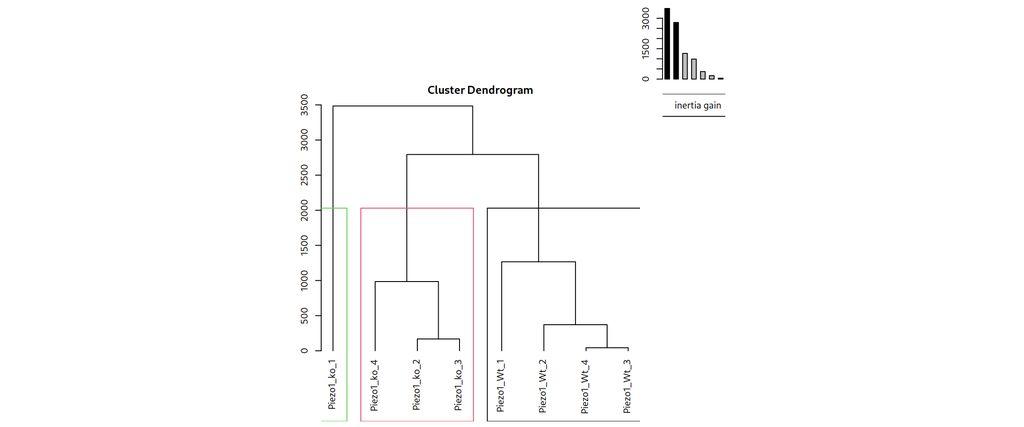

#### **PCA representation of 1 and 2 axis with individuals coloured by its cluster membership. The first 3 significant PCA dimensions are used for HCPC**

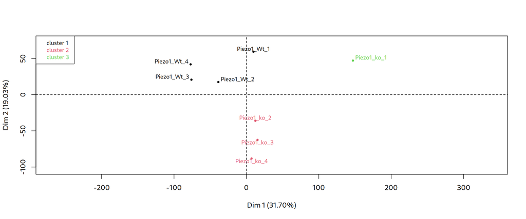

#### **Representation of correlation and P value of numeric factors and PCA dimensions**

None of the factors were significantly associated with any dimension

#### **Representation of R2 and P value of qualitative factors and PCA dimensions**

None of the factors were significantly associated with any dimension

#### **Representation of estimated coordinated from barycentre and P value of qualitative factors and PCA dimensions**

None of the categories were significantly associated with any dimension

### **Visualizing normalization results**

#### Representation of cpm unfiltered data:

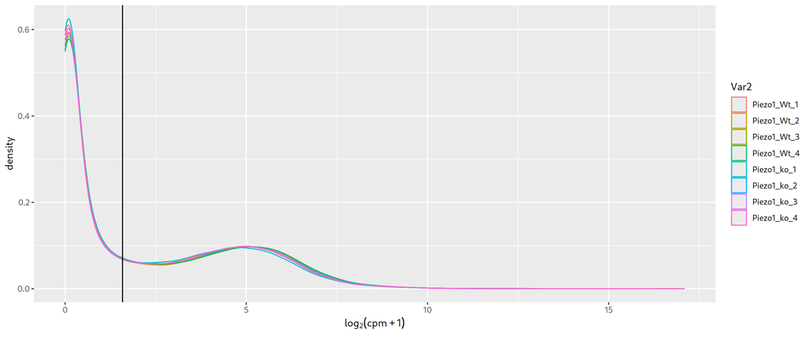

#### Before normalization:

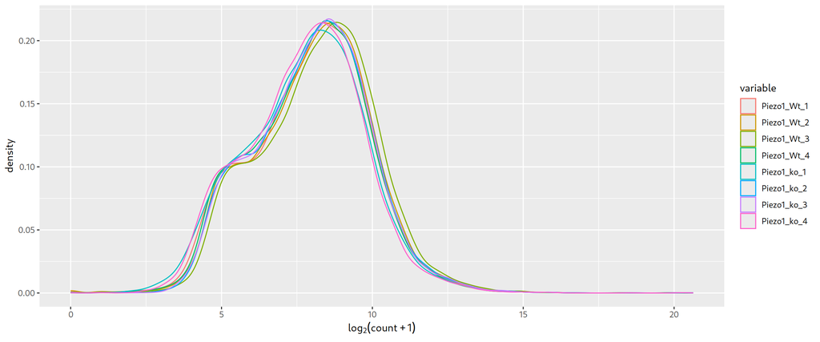

#### After normalization:

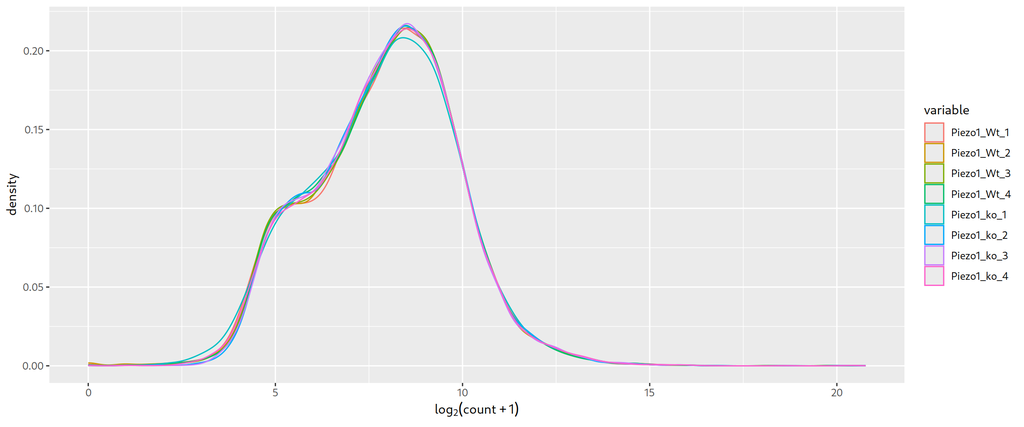

### **Count metrics by sample ranks**

#### **Sample rank versus total counts**

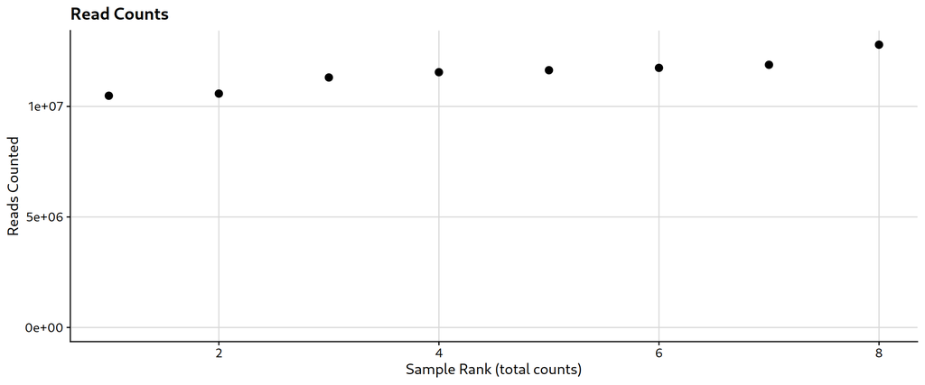

Sample rank is the position a sample holds after sorting by total counts

### **Statistics of expressed genes**

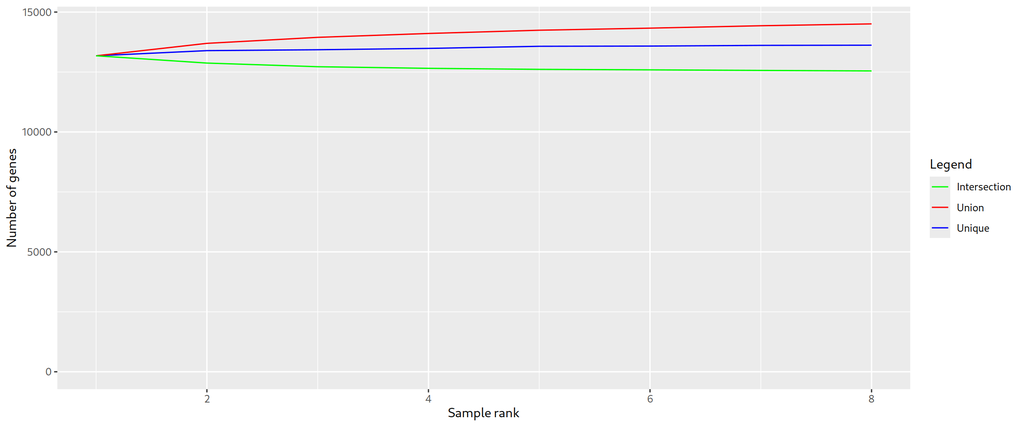

Samples are ranked by total expressed genes. Union of expressed genes represents the cumulative total expressed genes (sum of all genes expressed in any sample up to current sample, expected to increase with sample rank). Intersection of expressed genes represents the cumulative intersection of expressed genes (sum of genes expressed in all samples up to current sample, expected to decrease with sample rank).

#### **Mean count distribution by filter**

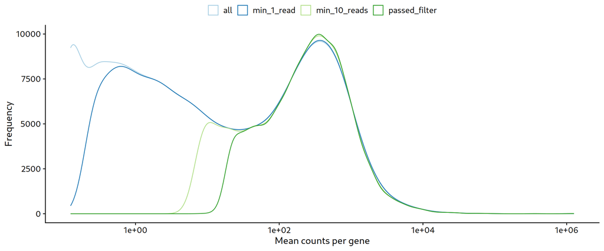

This plot represents the mean counts distribution per gene, classified by filters

### Gene counts variance distribution

Variance of gene counts across samples are represented. Genes with lower variance than selected threshold (dashed grey line) were filtered out.

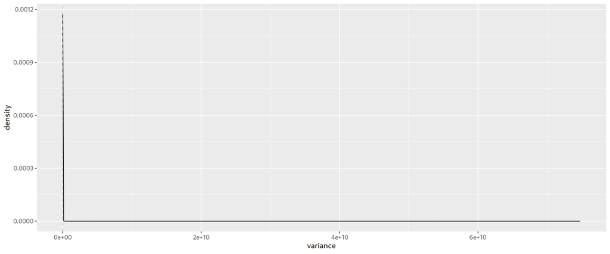

### **Samples differences by all counts normalized**:

All counts were normalizated by default (see options below) algorithm. This count were scaled by log10 and plotted in a heatmap.

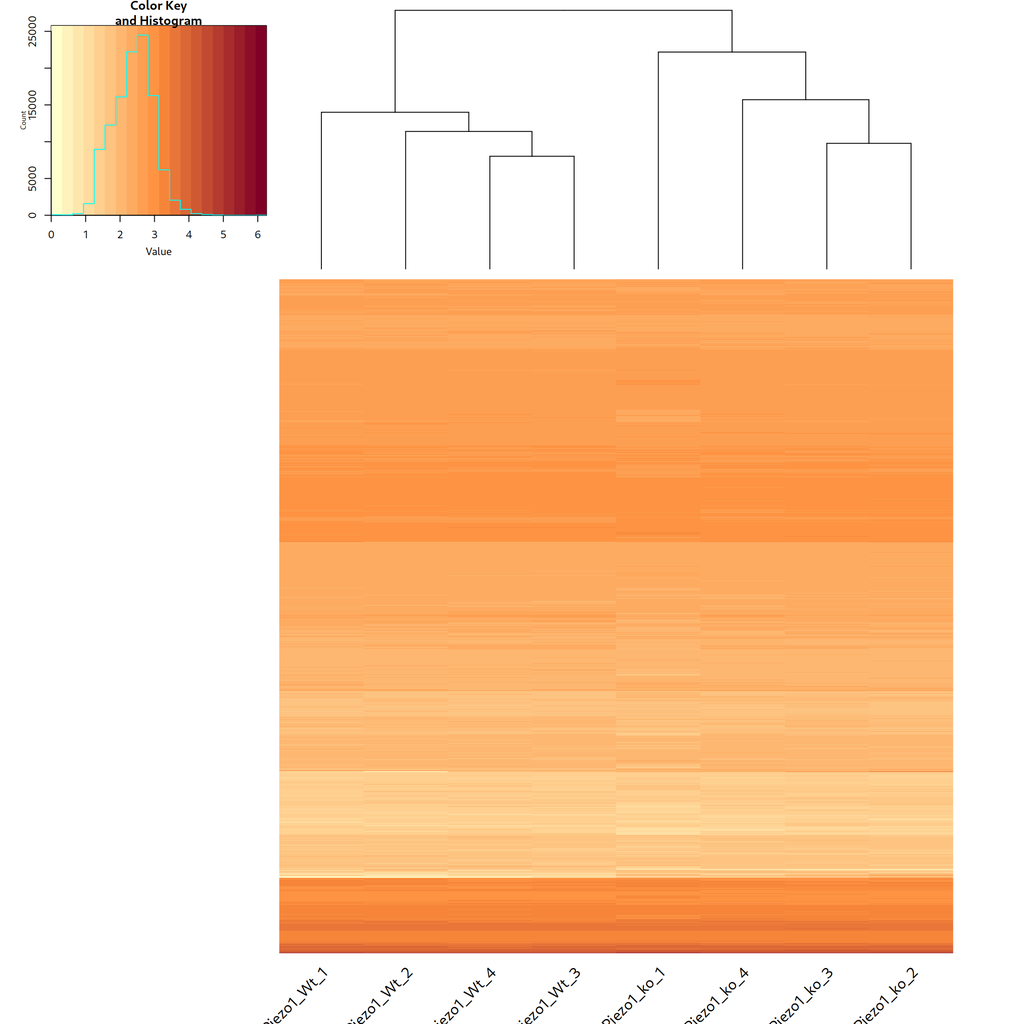

### **Percentages of reads per sample mapping to the most highly expressed genes**

|  | Piezo1_Wt_1 | Piezo1_Wt_2 | Piezo1_Wt_3 | Piezo1_Wt_4 | Piezo1_ko_1 | Piezo1_ko_2 | Piezo1_ko_3 | Piezo1_ko_4 |
| --- | --- | --- | --- | --- | --- | --- | --- | --- |
| ENSMUSG00000001506 | 10.777 | 10.129 | 9.211 | 9.290 | 14.033 | 11.102 | 11.073 | 12.746 |
| ENSMUSG00000029661 | 10.170 | 9.469 | 8.852 | 8.898 | 12.812 | 9.958 | 10.289 | 11.554 |
| ENSMUSG00000018593 | 3.105 | 2.906 | 2.737 | 2.669 | 3.729 | 3.149 | 3.342 | 3.573 |
| ENSMUSG00000064351 | 0.611 | 0.691 | 0.795 | 0.805 | 0.840 | 1.028 | 0.937 | 0.718 |
| ENSMUSG00000029304 | 0.794 | 0.654 | 0.677 | 0.666 | 0.869 | 0.544 | 0.605 | 0.467 |

## **Details of the input data**

### **First group of samples (to be referred to as control in the rest of the report)**

| Sample Names: |
| --- |
| Piezo1_Wt_1 |
| Piezo1_Wt_2 |
| Piezo1_Wt_3 |
| Piezo1_Wt_4 |

### **Second group of samples (to be referred to as treatment in the rest of the report)**

| Sample Names: |
| --- |
| Piezo1_ko_1 |
| Piezo1_ko_2 |
| Piezo1_ko_3 |
| Piezo1_ko_4 |

Note: A positive log fold change shows higher expression in the treatment group; a negative log fold change represents higher expression in the control group.

## **DEgenes Hunter results**

### **Gene classification by DEgenes Hunter**

DEgenes Hunter uses multiple DE detection packages to analyse all genes in the input count table and labels them accordingly:

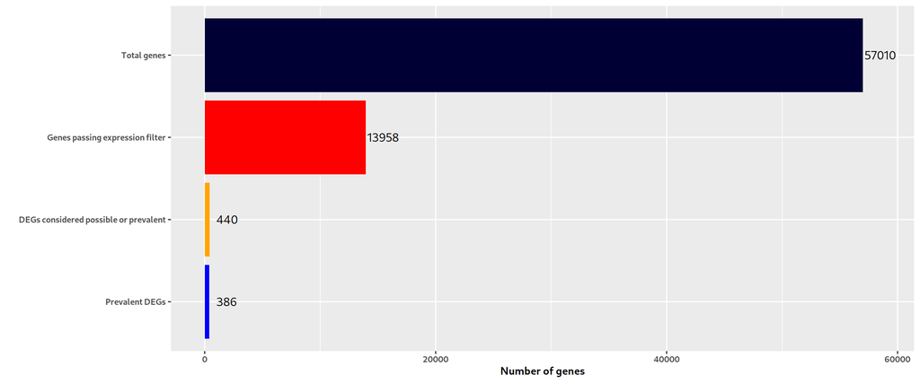

### **Package DEG detection stats**

This is the Venn Diagram of all possible DE genes (DEGs) according to at least on of the DE detection packages employed:

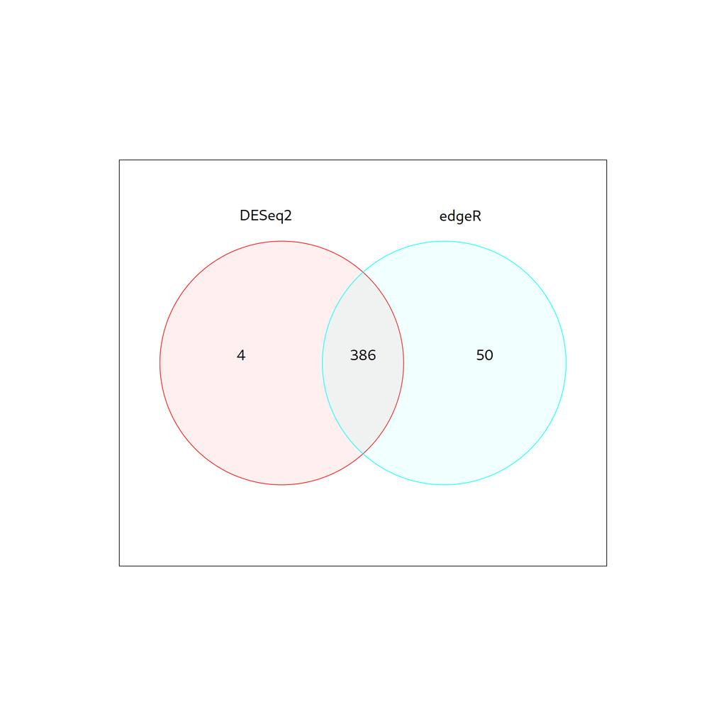

### **Plot showing variability between different DEG detection methods in terms of logFC calculation**

This graph shows logFC calculated (y-axis) for each package (points) and gene (x-axis). Only genes with variability over 0.01 will be plotted. This representation allows to user to observe the behaviour of each DE package and see if one of them has atypical results.

If there are no genes showing sufficient variance in estimated logFC accross methods, no plot will be produced and a warning message will be given.

[output not shown]

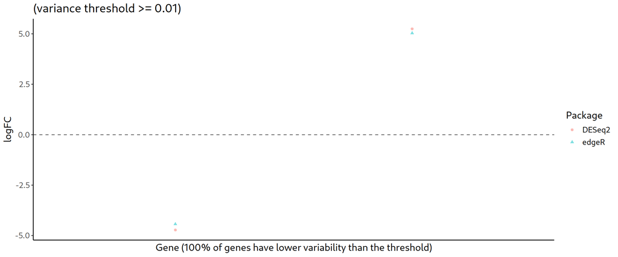

### **FDR gene-wise benchmarking**

Benchmark of false positive calling:

Boxplot of FDR values among all genes with an FDR <= 0.05 in at least one DE detection package

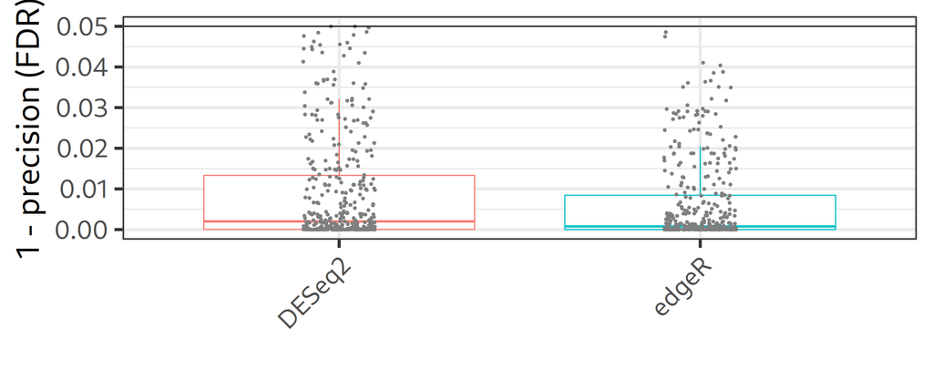

### **FDR Volcano Plot showing log 2 fold change vs. FDR**

The red horizontal line represents the chosen FDR threshold of 0.05. The black lines represent other values.

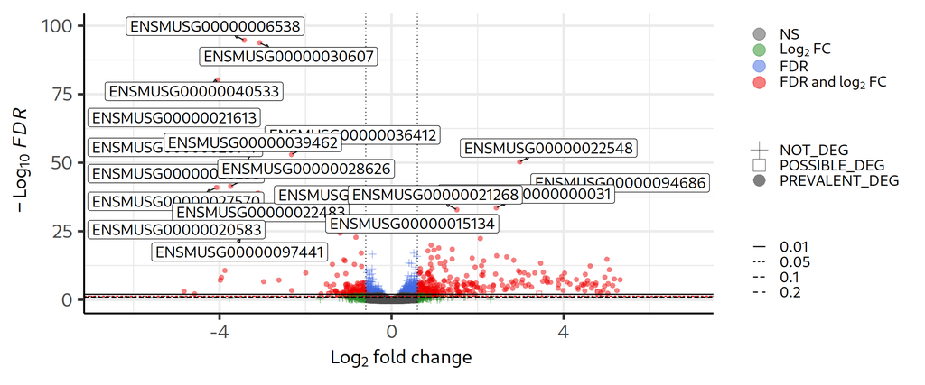

### **Principal Component Analysis**

This is a PCA plot of the count values normalized following the default method and then they are scaled:

#### **Inertia plot exploring variance explained by dimensions**

Graphical representation of PCA dimensions. The bars represent the percentage of total variance that summarize each dimension. The line measures the percentage of total variance accumulated in previous dimensions. The color distinguishes between significan or no significant dimensions. Only significant dimensions will be considered in the following plots.

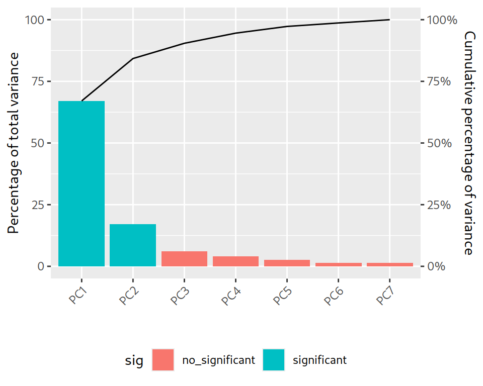

#### **Distribution of Eigenvectors**

The eigenvector contains the weights of each gene for the PC. Here are represented the distributions of the weights of each eigenvector. The vertical lines represent the quantiles.

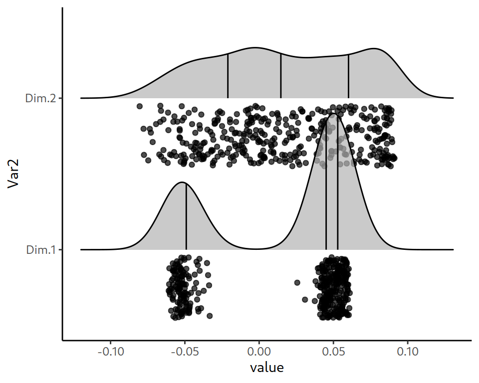

#### **Comparison of significant dimensions significant dimensions**

This plot compare the position of samples and their distribution in the significant dimensions. The color differenciate between the control (red) and treat (blue) samples.

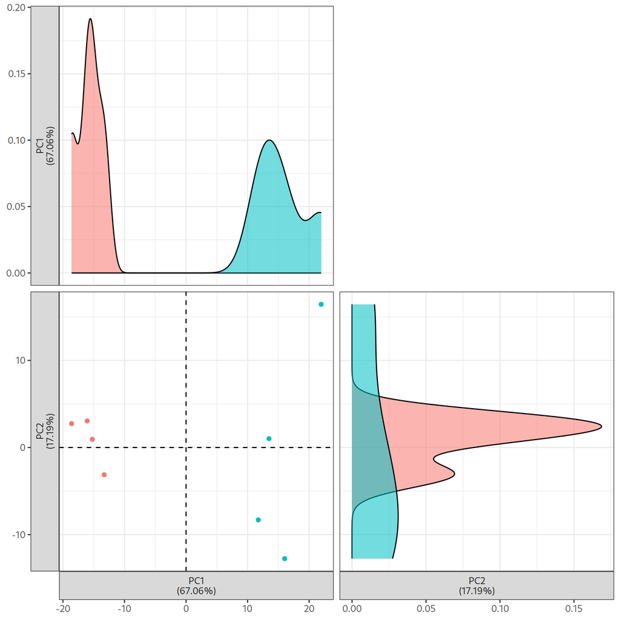

#### **Representation of the samples in the two first dimension of PCA**

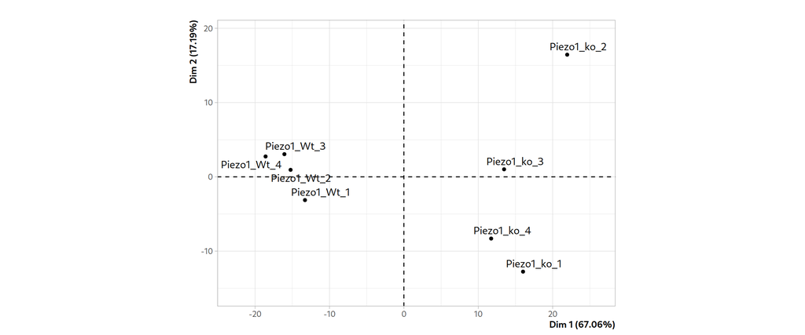

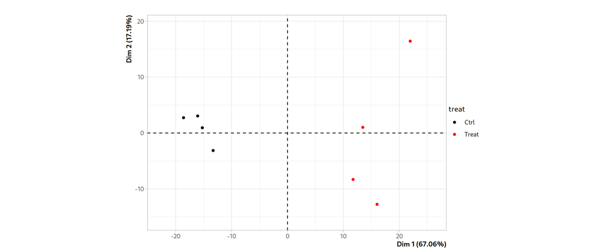

#### **Representation of the samples and the categories of qualitative valiables in the two first dimension of PCA**

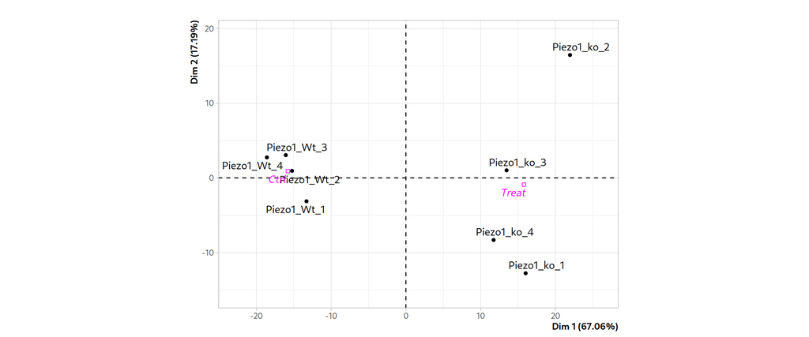

#### **Hierarchical clustering of individuals using first 2 significant PCA dimensions**

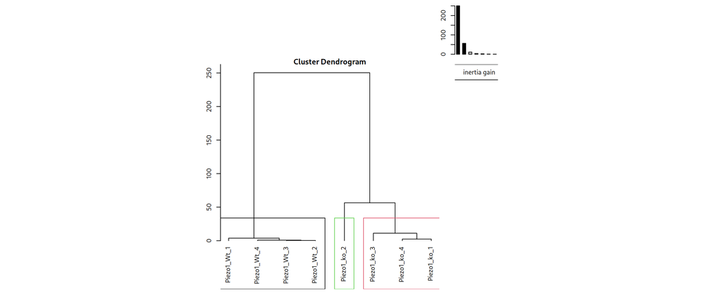

#### **PCA representation of 1 and 2 axis with individuals coloured by its cluster membership. The first 2 significant PCA dimensions are used for HCPC**

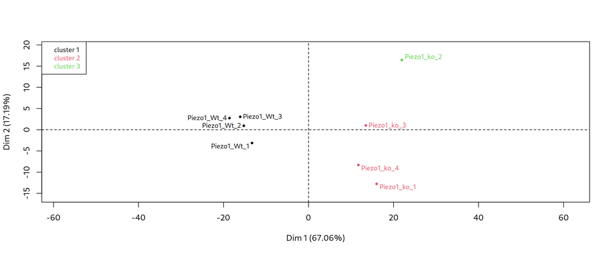

#### **Representation of correlation and P value of numeric factors and PCA dimensions**

None of the factors were significantly associated with any dimension

#### **Representation of R2 and P value of qualitative factors and PCA dimensions**

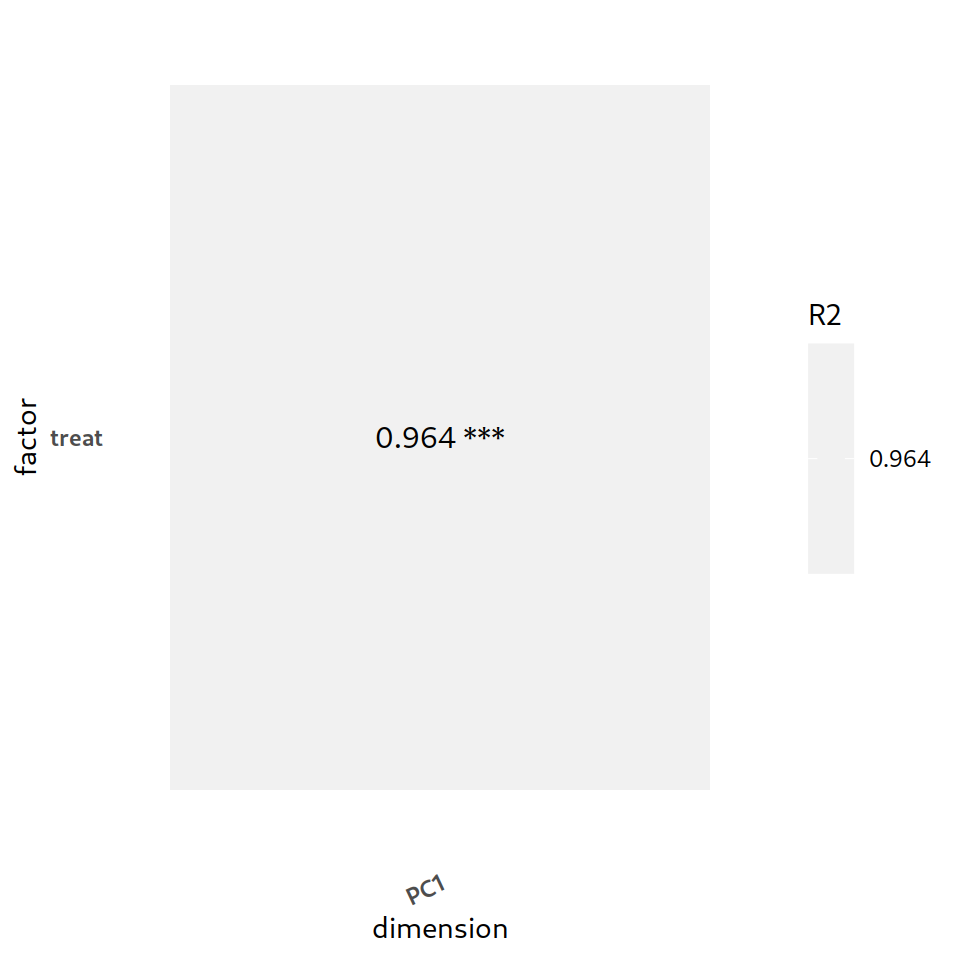

#### **Representation of estimated coordinated from barycentre and P value of qualitative factors and PCA dimensions**

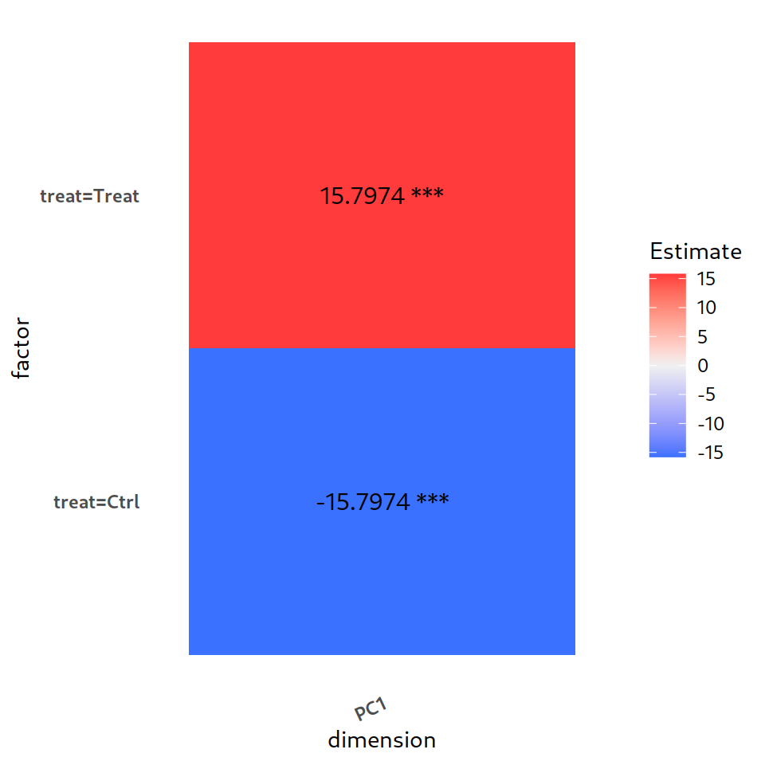

The complete results of the DEgenes Hunter differential expression analysis can be found in the “hunter_results_table.txt” file in the Common_results folder

## **DE detection package specific results**

Various plots specific to each package are shown below:

### **DESeq2 size factor vs. sample rank**

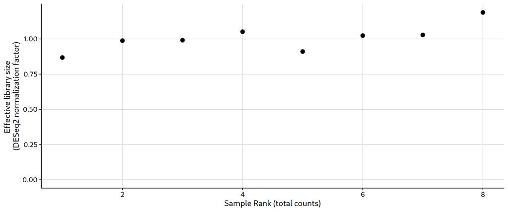

The effective library size is the factor used by DESeq2 normalization algorithm for each sample. The effective library size must be dependent of raw library size.

### **DESeq2 normalization effects**:

This plot compares the effective library size with raw library size

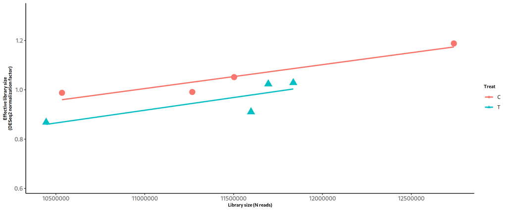

The effective library size is the factor used by DESeq2 normalization algorithm for each sample. The effective library size must be dependent of raw library size.

### **DESeq2 MA plot**:

This is the MA plot from DESeq2 package:

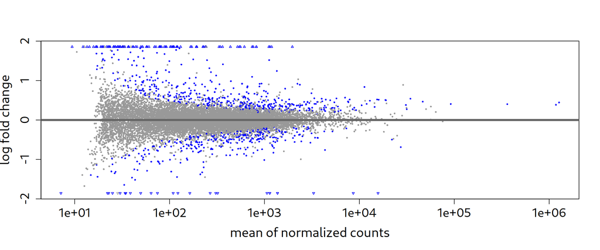

A table containing the DESeq2 DEGs is provided: in Results_DESeq2/DEgenes_DESEq2.txt

A table containing the DESeq2 normalized counts is provided in Results_DESeq2/Normalized_counts_DESEq2.txt

### **Differences between samples by PREVALENT DEGs normalized counts**:

Counts of prevalent DEGs were normalizated by DESeq2 algorithm. This count were scaled by log10 and plotted in a heatmap.

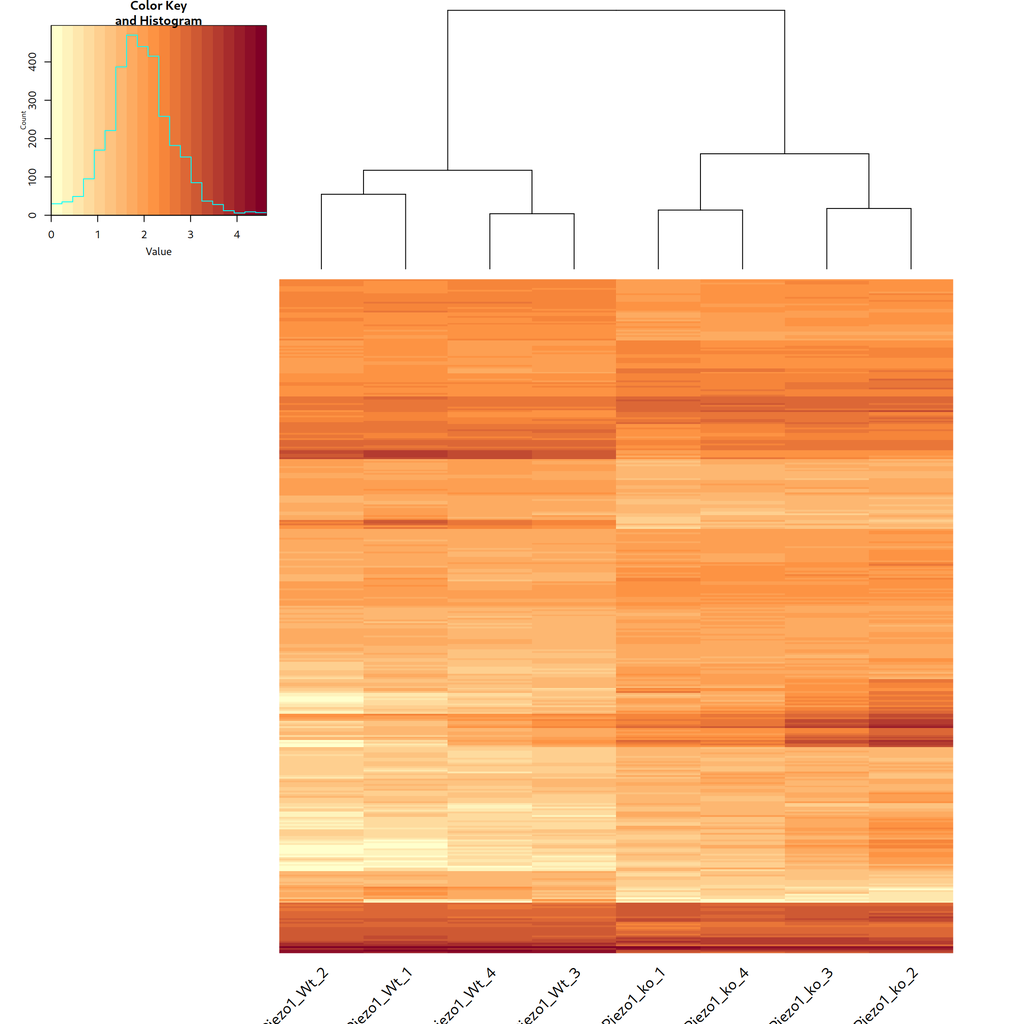

### **edgeR MA plot**

This is the MA plot from edgeR package:

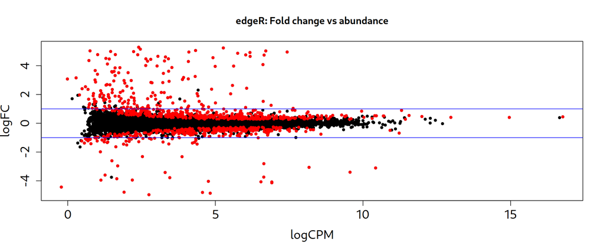

Differential gene expression data can be visualized as MA-plots (log ratio versus abundance) where each dot represents a gene. The differentially expressed genes are colored red and the non-differentially expressed ones are colored black.

A table containing the edgeR DEGs is provided in Results_edgeR/DEgenes_edgeR.txt

A table containing the edgeR normalized counts is provided in Results_edgeR/Normalized_counts_edgeR.txt

## **Detailed package results comparation**

This is an advanced section in order to compare the output of the packages used to perform data analysis. The data shown here does not necessarilly have any biological implication.

### **P-value Distributions**

Distributions of p-values, unadjusted and adjusted for multiple testing (FDR)

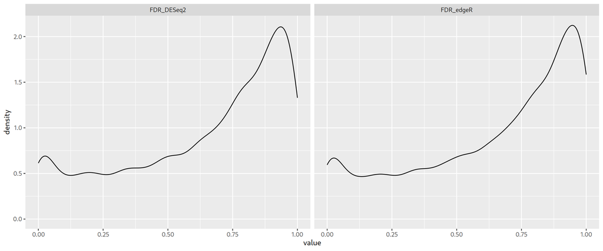

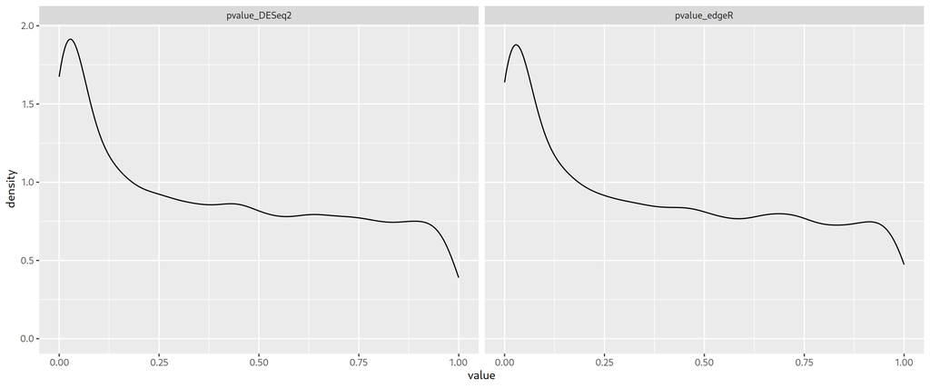

### **FDR Correlations**

Correlations of adjusted p-values, adjusted for multiple testing (FDR) and for log Fold Change.

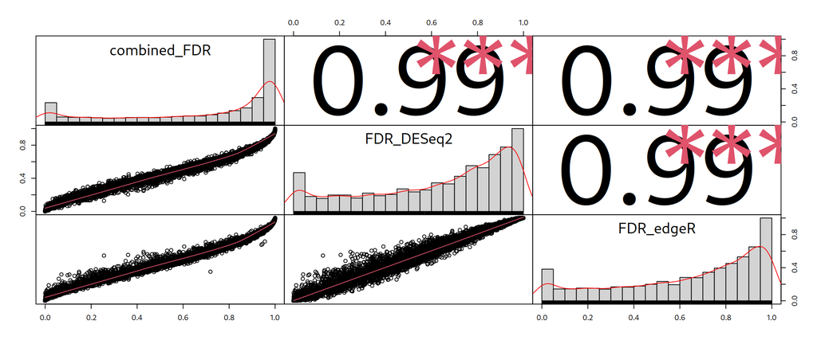

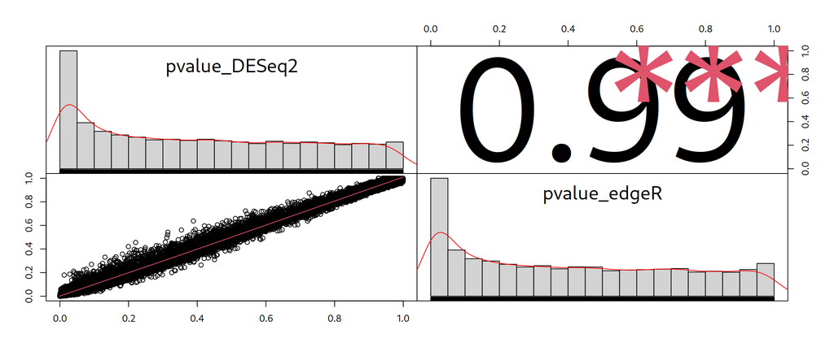

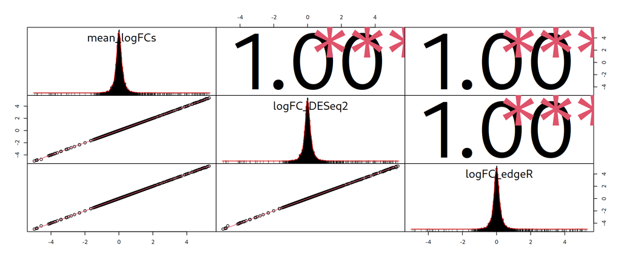

### **Values of options used to run DEGenesHunter**

First column contains the option names; second column contains the given values for each option in this run.

|  | opt |
| --- | --- |
| input_file | /mnt/home/users/bio_369_uma/jmperez/hunter/case4/count_table.txt |
| pseudocounts | FALSE |
| reads | 2 |
| count_var_quantile | 0 |
| minlibraries | 2 |
| filter_type | separate |
| output_files | /mnt/home/users/bio_369_uma/jmperez/hunter/case4/results_f06/ |
| p_val_cutoff | 0.05 |
| lfc | 0.6 |
| modules | DE |
| minpack_common | 4 |
| target_file | target_file |
| model_variables |  |
| numerics_as_factors | FALSE |
| string_factors |  |
| numeric_factors |  |
| WGCNA_memory | 5000 |
| WGCNA_norm_method | DESeq2 |
| WGCNA_deepsplit | 2 |
| WGCNA_min_genes_cluster | 20 |
| WGCNA_detectcutHeight | 0.995 |
| WGCNA_mergecutHeight | 0.25 |
| WGCNA_all | FALSE |
| WGCNA_blockwiseNetworkType | signed |
| WGCNA_blockwiseTOMType | signed |
| WGCNA_minCoreKME | 0.7 |
| WGCNA_minKMEtoStay | 0.5 |
| WGCNA_corType | pearson |
| multifactorial |  |
| help | FALSE |